# 1_task

**Task 1: Objective vs Subjective Treatment Response**

**Task 1 Goal and Strategy:** The treatment may reduce Monthly Migraine Days (MMDs), but this does not always translate into a proportional improvement in patient-reported outcomes (e.g., HIT-6, MIDAS, HADS). In this task we quantify the objective-subjective mismatch during long-term anti-CGRP treatment.

We proceed in two steps: **1. Average longitudinal change:** We fit separate linear mixed-effects models for MMDs (objective) and HIT-6 (subjective), accounting for repeated measures with a patient-specific random intercept.

**2. Mismatch at Cycle 1:** We define objective and subjective responders using pre-specified clinical thresholds and estimate the proportion of discordant patients (objective responder, but not subjective responder).

A sensitivity analysis repeats the same workflow under an alternative longitudinal imputation strategy (LOCF) to assess robustness.

```r
# ---- Setup ----
if (!requireNamespace("rstudioapi", quietly = TRUE)) install.packages("rstudioapi")
library(tidyverse)

# Robust project root handling (works in RStudio, doesn't crash elsewhere)
if (requireNamespace("rstudioapi", quietly = TRUE) && rstudioapi::isAvailable()) {
  prj <- rstudioapi::getActiveProject()
  if (!is.null(prj) && nzchar(prj)) setwd(prj)
}
cat("WD:", getwd(), "\n")
```

```
## WD: /Users/sabinagallo/Desktop/Year 3/medical application/MedicalApplication_Project/scripts
```

```r
# Load baseline (clean + imputed version saved in preprocessing step)
baseline_imp <- readRDS("data/processed/baseline_imputed.rds")

# Load analysis datasets created in 02.preprocessing_missing_imputation.Rmd
data_main <- readRDS("data/processed/data_main_analysis.rds")
data_sens <- readRDS("data/processed/data_sens_analysis.rds")

# Output folders
dir.create("outputs/task1", recursive = TRUE, showWarnings = FALSE)
dir.create("outputs/task1/figures", recursive = TRUE, showWarnings = FALSE)

# Quick checks
cat("Rows (main):", nrow(data_main), "\n")
```

```
## Rows (main): 2685
```

```r
cat("Rows (sens):", nrow(data_sens), "\n")
```

```
## Rows (sens): 2685
```

```r
cat("Unique subjects (main):", n_distinct(data_main$SUBJECT_ID), "\n")
```

```
## Unique subjects (main): 179
```

```r
cat("Unique subjects (sens):", n_distinct(data_sens$SUBJECT_ID), "\n")
```

```
## Unique subjects (sens): 179
```

The following setup loads the preprocessed datasets created in the previous steps and defines the analysis environment for Task 1. Two datasets are used: - a main dataset based on linear interpolation; - a sensitivity dataset based on LOCF imputation. =============================================================================== Analytical dataset: we build a minimal longitudinal dataset for Task 1 including subject identifiers, time variables (cycle, month), and the two main outcomes (MMDs and HIT-6). Optional variables (HADS-A/D, INT, MIDAS) are retained when available. This dataset will be used both for mixed models and for responder/mismatch definitions.

```r
#We require SUBJECT_ID, CYCLE, MONTH, MMDs, HIT6
required_cols <- c("SUBJECT_ID", "CYCLE", "MONTH", "MMDs", "HIT6")
stopifnot(all(required_cols %in% names(data_main)))
stopifnot(all(required_cols %in% names(data_sens)))

keep_cols <- c("SUBJECT_ID", "CYCLE", "MONTH", "MMDs", "HIT6", "HADSA",
               "HADSD","INT", "MIDAS")

# MAIN dataset for Task 1 (interpolation-based)
data_task1_main <- data_main %>%
  # Keep only relevant columns (optional variables are kept only if present)
  dplyr::select(dplyr::any_of(keep_cols)) %>%
  dplyr::mutate(
    SUBJECT_ID = factor(SUBJECT_ID),
    CYCLE = factor(CYCLE),
    MONTH_num = as.numeric(as.character(MONTH)),
    MONTH = factor(as.character(MONTH),
                   levels = c("1", "3", "6", "9", "12"),
                   ordered = FALSE)
  )

# SENSITIVITY dataset for Task 1 (LOCF-based)
data_task1_sens <- data_sens %>%
  # Keep only relevant columns (optional variables are kept only if present)
  dplyr::select(dplyr::any_of(keep_cols)) %>%
  dplyr::mutate(
    SUBJECT_ID = factor(SUBJECT_ID),
    CYCLE = factor(CYCLE),
    # Keep month as an ordered factor (1, 3, 6, 9, 12)
    MONTH_num = as.numeric(as.character(MONTH)),
    MONTH = factor(as.character(MONTH),
                   levels = c("1", "3", "6", "9", "12"),
                   ordered = FALSE)
  )


cat("Task1 MAIN dim:", dim(data_task1_main), "\n")
```

```
## Task1 MAIN dim: 2685 10
```

```r
cat("Missingness MAIN (MMDs):", mean(is.na(data_task1_main$MMDs)), "\n")
```

```
## Missingness MAIN (MMDs): 0.4
```

```r
cat("Missingness MAIN (HIT6):", mean(is.na(data_task1_main$HIT6)), "\n")
```

```
## Missingness MAIN (HIT6): 0.4197393
```

```r
cat("Task1 SENS dim:", dim(data_task1_sens), "\n")
```

```
## Task1 SENS dim: 2685 10
```

```r
cat("Missingness SENS (MMDs):", mean(is.na(data_task1_sens$MMDs)), "\n")
```

```
## Missingness SENS (MMDs): 0.3445065
```

```r
cat("Missingness SENS (HIT6):", mean(is.na(data_task1_sens$HIT6)), "\n")
```

```
## Missingness SENS (HIT6): 0.3772812
```

# We created two parallel longitudinal datasets (MAIN and SENS) under alternative missing-data strategies. Follow-up time is represented as MONTH ( a factor used for ordered plotting) and as MONTH_num (a numeric variable used in mixed-effects models). Missingness summaries are reported as a sanity check before model fitting.

Mixed models (average effects over time): We fit two separate linear mixed models with a random intercept for each patient. This estimates the average change over time while accounting for repeated measures within subjects.

```r
# Load required packages
if (!requireNamespace("lme4", quietly = TRUE)) install.packages("lme4")
if (!requireNamespace("lmerTest", quietly = TRUE)) install.packages("lmerTest")

library(lme4)
library(lmerTest)

# MAIN dataset only (interpolation-based)
dat <- data_task1_main

# ---- Model A: Objective outcome (Monthly Migraine Days) ----
mod_mmds <- lmer(
  MMDs ~ CYCLE + MONTH_num + (1 | SUBJECT_ID),
  data = dat,
  REML = FALSE
)

# ---- Model B: Subjective outcome (HIT-6) ----
mod_hit6 <- lmer(
  HIT6 ~ CYCLE + MONTH_num + (1 | SUBJECT_ID),
  data = dat,
  REML = FALSE
)

summary(mod_mmds)
```

```
## Linear mixed model fit by maximum likelihood . t-tests use Satterthwaite's
##   method [lmerModLmerTest]
## Formula: MMDs ~ CYCLE + MONTH_num + (1 | SUBJECT_ID)
##    Data: dat
##
##       AIC       BIC    logLik -2*log(L)  df.resid
##   10675.9   10708.2   -5332.0   10663.9      1605
##
## Scaled residuals:
##     Min      1Q  Median      3Q     Max
## -3.5902 -0.6257 -0.0550  0.5561  3.3046
##
## Random effects:
##  Groups     Name        Variance Std.Dev.
##  SUBJECT_ID (Intercept) 37.88    6.155
##  Residual               34.33    5.859
## Number of obs: 1611, groups:  SUBJECT_ID, 179
##
## Fixed effects:
##               Estimate Std. Error         df t value Pr(>|t|)
## (Intercept)   18.76273    0.54834  250.58502  34.217  < 2e-16 ***
## CYCLE2        -1.28139    0.38560 1506.03735  -3.323 0.000911 ***
## CYCLE3        -2.26941    0.40451 1514.11599  -5.610  2.4e-08 ***
## MONTH_num     -0.70782    0.03772 1445.20769 -18.767  < 2e-16 ***
## ---
## Signif. codes:  0 '***' 0.001 '**' 0.01 '*' 0.05 '.' 0.1 ' ' 1
##
## Correlation of Fixed Effects:
##           (Intr) CYCLE2 CYCLE3
## CYCLE2    -0.184
## CYCLE3    -0.176  0.458
## MONTH_num -0.376 -0.012 -0.009
```

```r
summary(mod_hit6)
```

```
## Linear mixed model fit by maximum likelihood . t-tests use Satterthwaite's
##   method [lmerModLmerTest]
## Formula: HIT6 ~ CYCLE + MONTH_num + (1 | SUBJECT_ID)
##    Data: dat
##
##       AIC       BIC    logLik -2*log(L)  df.resid
##   12164.5   12196.6   -6076.3   12152.5      1552
##
## Scaled residuals:
##     Min      1Q  Median      3Q     Max
## -4.7546 -0.3354  0.1337  0.5672  2.3815
##
## Random effects:
##  Groups     Name        Variance Std.Dev.
##  SUBJECT_ID (Intercept)  16.03    4.004
##  Residual               132.37   11.505
## Number of obs: 1558, groups:  SUBJECT_ID, 179
##
## Fixed effects:
##               Estimate Std. Error         df t value Pr(>|t|)
## (Intercept)   64.47238    0.70616  840.35792  91.300  < 2e-16 ***
## CYCLE2         3.02464    0.71785 1500.46865   4.213 2.66e-05 ***
## CYCLE3        -0.63105    0.77214 1549.25068  -0.817    0.414
## MONTH_num     -1.52063    0.07449 1448.44030 -20.414  < 2e-16 ***
## ---
## Signif. codes:  0 '***' 0.001 '**' 0.01 '*' 0.05 '.' 0.1 ' ' 1
##
## Correlation of Fixed Effects:
##           (Intr) CYCLE2 CYCLE3
## CYCLE2    -0.451
## CYCLE3    -0.370  0.445
## MONTH_num -0.584 -0.041 -0.038
```

```r
# Optional models (only if the variables exist)
mods_optional <- list()

if("HADSA" %in% names(dat)) {
  mods_optional$hadsa_main <- lmer(HADSA ~CYCLE + MONTH_num + (1 | SUBJECT_ID), data = dat, REML = FALSE)
}


if("HADSD" %in% names(dat)) {
  mods_optional$hadsd_main <- lmer(HADSD ~ CYCLE + MONTH_num + (1 | SUBJECT_ID), data = dat, REML = FALSE)
}

if (length(mods_optional) > 0) lapply(mods_optional, summary)
```

```
## $hadsa_main
## Linear mixed model fit by maximum likelihood . t-tests use Satterthwaite's
##   method [lmerModLmerTest]
## Formula: HADSA ~ CYCLE + MONTH_num + (1 | SUBJECT_ID)
##    Data: dat
##
##       AIC       BIC    logLik -2*log(L)  df.resid
##    5108.9    5137.3   -2548.5    5096.9       835
##
## Scaled residuals:
##     Min      1Q  Median      3Q     Max
## -1.5817 -0.3824 -0.1205  0.2291 15.5802
##
## Random effects:
##  Groups     Name        Variance Std.Dev.
##  SUBJECT_ID (Intercept)  7.423   2.724
##  Residual               21.837   4.673
## Number of obs: 841, groups:  SUBJECT_ID, 85
##
## Fixed effects:
##              Estimate Std. Error        df t value Pr(>|t|)
## (Intercept)   6.41259    0.52258 302.87924  12.271  < 2e-16 ***
## CYCLE2       -0.52305    0.42598 839.73625  -1.228  0.21984
## CYCLE3       -0.50944    0.43823 756.61462  -1.162  0.24541
## MONTH_num    -0.11415    0.04074 765.55217  -2.802  0.00521 **
## ---
## Signif. codes:  0 '***' 0.001 '**' 0.01 '*' 0.05 '.' 0.1 ' ' 1
##
## Correlation of Fixed Effects:
##           (Intr) CYCLE2 CYCLE3
## CYCLE2    -0.562
## CYCLE3    -0.416  0.508
## MONTH_num -0.472  0.013  0.003
##
## $hadsd_main
## Linear mixed model fit by maximum likelihood . t-tests use Satterthwaite's
##   method [lmerModLmerTest]
## Formula: HADSD ~ CYCLE + MONTH_num + (1 | SUBJECT_ID)
##    Data: dat
##
```

[output cut: 12 more lines]

```
##
## Fixed effects:
##              Estimate Std. Error        df t value Pr(>|t|)
## (Intercept)   5.78702    0.48929 148.51554  11.827  < 2e-16 ***
## CYCLE2        0.32650    0.27533 795.40433   1.186 0.236036
## CYCLE3        0.54012    0.27336 755.35899   1.976 0.048534 *
## MONTH_num    -0.09578    0.02550 760.68477  -3.756 0.000186 ***
## ---
## Signif. codes:  0 '***' 0.001 '**' 0.01 '*' 0.05 '.' 0.1 ' ' 1
##
## Correlation of Fixed Effects:
##           (Intr) CYCLE2 CYCLE3
## CYCLE2    -0.399
## CYCLE3    -0.277  0.490
## MONTH_num -0.309  0.008  0.003
```

Follow-up time is encoded using the scheduled visit months (1, 3, 6, 9, 12) as a numeric variable (MONTH_num). This avoids polynomial contrasts from ordered factors and yields an interpretable fixed effect representing the average change associated with one additional month of follow-up, while still accounting for repeated measurements through a subject-specific random intercept.

Optional HADS models are fitted only when the corresponding outcomes are available; therefore, estimates may rely on different effective sample sizes and should be interpreted accordingly.

Export model results: we exported fixed effects tables (estimate + 95% CI) and created mean +SE trend plots.

```r
# Packages for tidying model outputs
if (!requireNamespace("broom.mixed", quietly = TRUE)) install.packages("broom.mixed")
library(broom.mixed)

# ---- Export fixed effects tables (beta, SE, CI) ----
fx_mmds_main <- tidy(mod_mmds, effects = "fixed", conf.int = TRUE)
fx_hit6_main <- tidy(mod_hit6, effects = "fixed", conf.int = TRUE)

dir.create("outputs/task1", recursive = TRUE, showWarnings = FALSE)

readr::write_csv(fx_mmds_main, "outputs/task1/fixed_effects_mmds_main.csv")
readr::write_csv(fx_hit6_main, "outputs/task1/fixed_effects_hit6_main.csv")

# Optional models (if you fitted them in mods_optional)
if (exists("mods_optional") && length(mods_optional) > 0) {
  fx_optional_main <- purrr::imap_dfr(
    mods_optional,
    ~ tidy(.x, effects = "fixed", conf.int = TRUE) %>% dplyr::mutate(model = .y)
  )
  readr::write_csv(fx_optional_main, "outputs/task1/fixed_effects_optional_main.csv")
}

# Print in console for quick inspection
fx_mmds_main
```

```
## # A tibble: 4 × 9
##   effect term     estimate std.error statistic    df  p.value conf.low conf.high
##   <chr>  <chr>       <dbl>     <dbl>     <dbl> <dbl>    <dbl>    <dbl>     <dbl>
## 1 fixed  (Interc…   18.8      0.548      34.2   251. 2.01e-96   17.7      19.8
## 2 fixed  CYCLE2     -1.28     0.386      -3.32 1506. 9.11e- 4   -2.04     -0.525
## 3 fixed  CYCLE3     -2.27     0.405      -5.61 1514. 2.40e- 8   -3.06     -1.48
## 4 fixed  MONTH_n…   -0.708    0.0377    -18.8  1445. 1.70e-70   -0.782    -0.634
```

```r
fx_hit6_main
```

```
## # A tibble: 4 × 9
##   effect term     estimate std.error statistic    df  p.value conf.low conf.high
##   <chr>  <chr>       <dbl>     <dbl>     <dbl> <dbl>    <dbl>    <dbl>     <dbl>
## 1 fixed  (Interc…   64.5      0.706     91.3    840. 0           63.1     65.9
## 2 fixed  CYCLE2      3.02     0.718      4.21  1500. 2.66e- 5     1.62     4.43
## 3 fixed  CYCLE3     -0.631    0.772     -0.817 1549. 4.14e- 1    -2.15     0.884
## 4 fixed  MONTH_n…   -1.52     0.0745   -20.4   1448. 1.30e-81    -1.67    -1.37
```

Fixed-effects estimates (β), standard errors and 95% confidence intervals were exported for the MMDs and HIT-6 mixed models. These tables summarize the average association of cycle and follow-up month via each outcome, while accounting for within-patient repeated measurements via a random intercept. Optional models (HADS-A/D) were exported only when available.

=============================================================================== **Core plots (MAIN):** We summarise MMDs and HIT-6 at each scheduled visit (months 1, 3, 6, 9 ,12) within each treatment cycle and visualize mean ± standard error. This provides an interpretable view of average longitudinal trends and acts as a sanity check before the mismatch/responder analysis.

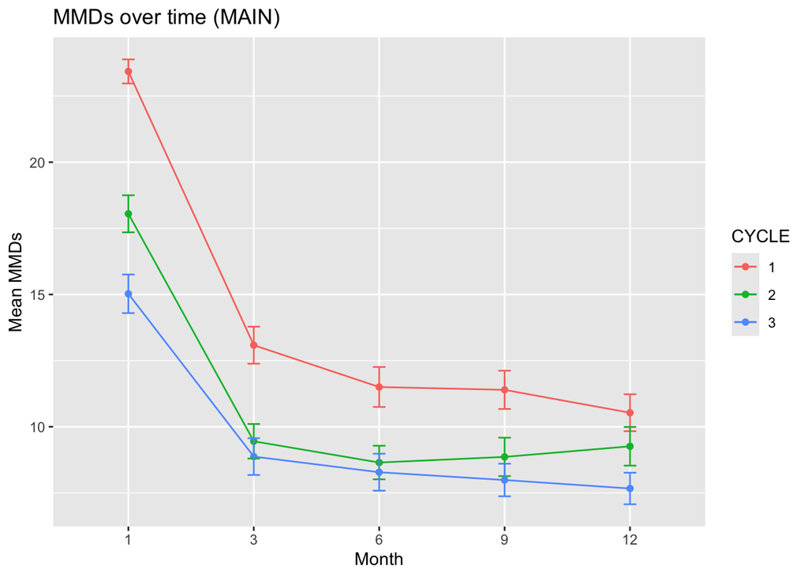

```r
# ---- Trend plots: mean ± SE by (CYCLE, MONTH) ----

#Core plots (MAIN dataset): mean ± trends by (CYCLE, MONTH)
dir.create("outputs/task1/figures", recursive = TRUE, showWarnings = FALSE)

# Compute summary statistics per timepoint
trend_main <- data_task1_main %>%
  group_by(CYCLE, MONTH) %>%
  summarise(
    n_MMDs = sum(!is.na(MMDs)),
    mean_MMDs = mean(MMDs, na.rm = TRUE),
    se_MMDs = if_else(n_MMDs > 1, sd(MMDs, na.rm = TRUE) / sqrt(n_MMDs), NA_real_),

    n_HIT6 = sum(!is.na(HIT6)),
    mean_HIT6 = mean(HIT6, na.rm = TRUE),
    se_HIT6 = if_else(n_HIT6 > 1, sd(HIT6, na.rm = TRUE) / sqrt(n_HIT6), NA_real_),
    .groups = "drop"
  )

# Plot: MMDs over time
p_mmds_main <- ggplot(trend_main, aes(x = MONTH, y = mean_MMDs, group = CYCLE,
                                 color = CYCLE)) +
  geom_line() +
  geom_point() +
  geom_errorbar(aes(ymin = mean_MMDs - se_MMDs, ymax = mean_MMDs + se_MMDs), width = 0.1) +
  labs(
    title = "MMDs over time (MAIN)",
    x = "Month",
    y = "Mean MMDs"
  )

# Plot: HIT-6 over time
p_hit6_main <- ggplot(trend_main, aes(x = MONTH, y = mean_HIT6, group = CYCLE,
                                      color = CYCLE)) +
  geom_line() +
  geom_point() +
  geom_errorbar(aes(ymin = mean_HIT6 - se_HIT6, ymax = mean_HIT6 + se_HIT6), width = 0.1) +
  labs(
    title = "HIT-6 over time by cycle",
    x = "Month",
    y = "Mean HIT-6"
  )

# Show plots
p_mmds_main
```

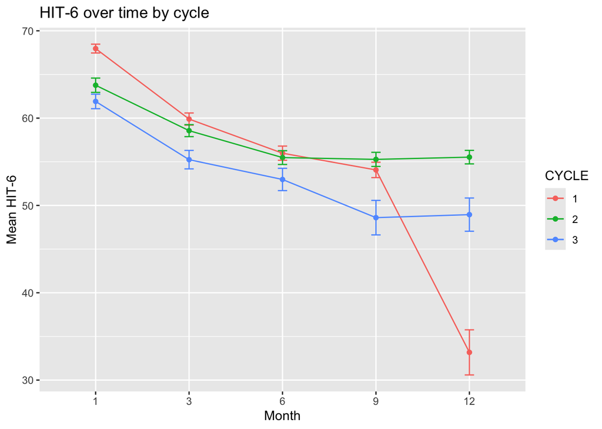

```r
p_hit6_main
```

```r
# Save plots
ggsave("outputs/task1/figures/trend_mmds_main.png", p_mmds_main, width = 7, height = 4)
ggsave("outputs/task1/figures/trend_hit6_main.png", p_hit6_main, width = 7, height = 4)

# Save trend table too
readr::write_csv(trend_main, "outputs/task1/trend_summary_main.csv")
```

The resulting figures show the average trajectories of objective (MMDs) and subjective (HIT-6) outcomes over follow-up. We saved both the plots and the aggregated summary table to be reused in the final report.

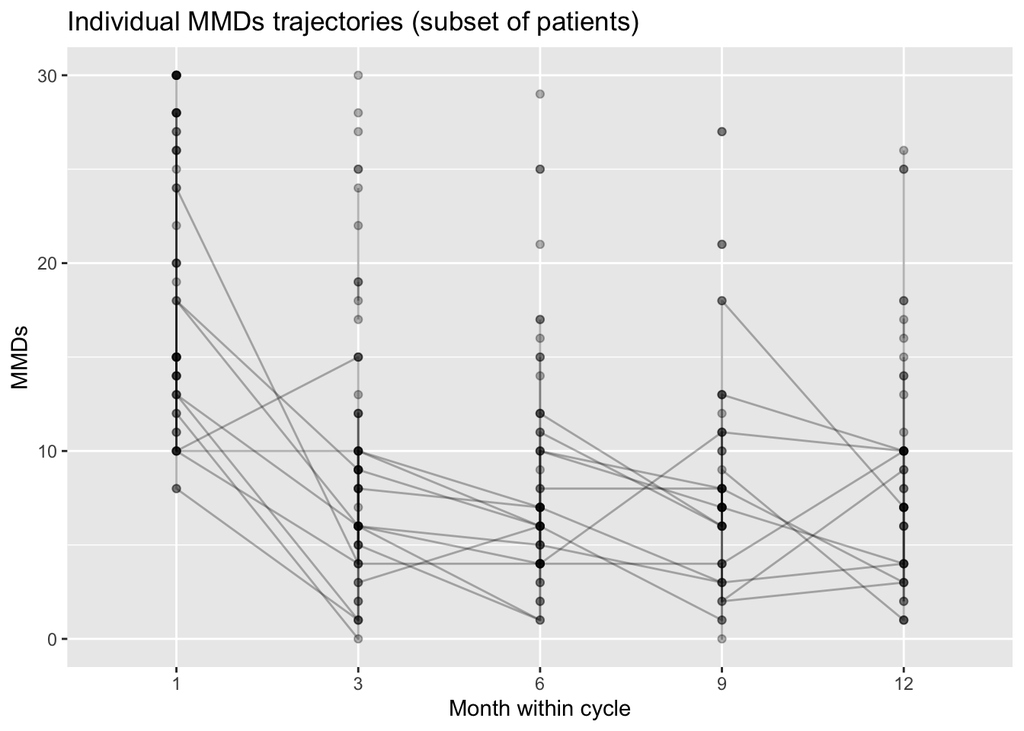

```r
set.seed(123)

# Sample a subset of patients to avoid overplotting
sample_ids <- sample(unique(data_task1_main$SUBJECT_ID), 30)

spaghetti_data <- data_task1_main %>%
  filter(SUBJECT_ID %in% sample_ids)

ggplot(spaghetti_data,
       aes(x = MONTH, y = MMDs, group = SUBJECT_ID)) +
  geom_line(alpha = 0.3) +
  geom_point(alpha = 0.3) +
  labs(
    title = "Individual MMDs trajectories (subset of patients)",
    x = "Month within cycle",
    y = "MMDs"
  )
```

As an exploratory visualization, we report individual longitudinal trajectories (spaghetti plot) for a subset of patients, highlighting the substantial inter-individual heterogeneity underlying the average trends.

=============================================================================== Now we move from average longitudinal trends to a patient-level definition of response in Cycle 1. We construct a start/end dataset by selecting Cycle 1 only and extracting, for each subject, baseline values at Month 1 and end-of-cycle values at Month 12 (or, if Month 12 is missing, the last observed month within Cycle 1, consistent with the “last available visit” rule).

We then compute two change metrics: - pct_change_MMDs = (MMDs_end − MMDs_start) / MMDs_start (objective percent change; negative values indicate improvement) - delta_HIT6 = HIT6_end − HIT6_start (subjective absolute change; negative values indicate improvement)

```r
# ------------------------------------------------------------------
# Select Cycle 1 and prepare time variable
# ------------------------------------------------------------------

c1 <- data_task1_main %>%
  filter(CYCLE == "1") %>%
  mutate(
    # Convert ordered MONTH factor to numeric for comparisons
    month_num = as.numeric(as.character(MONTH))
  ) %>%
  arrange(SUBJECT_ID, month_num)

cat("Cycle 1 rows:", nrow(c1), "\n")
```

```
## Cycle 1 rows: 895
```

```r
cat("Unique patients in Cycle 1:", n_distinct(c1$SUBJECT_ID), "\n")
```

```
## Unique patients in Cycle 1: 179
```

```r
# ------------------------------------------------------------------
# Define start of cycle (Month 1)
# ------------------------------------------------------------------
# Start-of-cycle values are taken at MONTH == 1

c1_start <- c1 %>%
  filter(month_num == 1) %>%
  select(
    SUBJECT_ID,
    MMDs_start = MMDs,
    HIT6_start = HIT6
  )

cat("Patients with start-of-cycle data:", nrow(c1_start), "\n")
```

```
## Patients with start-of-cycle data: 179
```

```r
# ------------------------------------------------------------------
# Define end of cycle
# ------------------------------------------------------------------
# End-of-cycle is defined as:
# - Month 12 if available
# - Otherwise, the last observed month within Cycle 1

c1_end <- c1 %>%
  group_by(SUBJECT_ID) %>%
  filter(!all(is.na(month_num))) %>%
  filter(month_num == max(month_num, na.rm = TRUE)) %>%
  slice_tail(n = 1) %>%
  ungroup() %>%
  select(
    SUBJECT_ID,
    end_month = month_num,
    MMDs_end = MMDs,
    HIT6_end = HIT6
  )

cat("Patients with end-of-cycle data:", nrow(c1_end), "\n")
```

```
## Patients with end-of-cycle data: 179
```

```r
cat("End month distribution:\n")
```

```
## End month distribution:
```

```r
print(table(c1_end$end_month, useNA = "ifany"))
```

```
##
##  12
## 179
```

```r
# ------------------------------------------------------------------
# Merge start and end and compute changes
# ------------------------------------------------------------------
# Only patients with both start and end are retained

c1_change <- c1_start %>%
  inner_join(c1_end, by = "SUBJECT_ID") %>%
  mutate(
    # Objective change: percentage change in MMDs
    # Negative values indicate improvement
    pct_change_MMDs = if_else(
      !is.na(MMDs_start) & MMDs_start > 0,
      (MMDs_end - MMDs_start) / MMDs_start,
      NA_real_
    ),

    # Subjective change: absolute change in HIT-6
    # Negative values indicate improvement
    delta_HIT6 = HIT6_end - HIT6_start
  )

cat("Patients with valid start/end in Cycle 1:", nrow(c1_change), "\n")
```

```
## Patients with valid start/end in Cycle 1: 179
```

The resulting dataset (c1_change) contains one row per subject with Cycle 1 start and end measurements and the corresponding change metrics. Only subjects with both start-of-cycle and end-of-cycle information are retained (inner_join), ensuring that responder classification is based on complete paired measurements.

===============================================================================

In this next step, we will apply pre-specified clinical thresholds to pct_change_MMDs and delta_HIT6 to define objective and subjective responders and identify discordant profiles.

Now we classify Cycle 1 responses using clinically motivated thresholds. An objective responder is defined as a ≥ 50% reduction in MMDs from Month 1 to Month 12 (pct_change_MMD ≤ -0.50). A subjective responder is defined as a ≥ 5-point reduction in HIT-6 (delta_HIT6 ≤ -5), corresponding to the Minimal Important Clinical Difference (MCID) reported in the literature.

We then define discordance as objective response without subjective improvement (obj-resp = 1 & subj_resp = 0) and label concordant responders (obj_resp = 1 & subj_resp = 1)

```r
# ------------------------------------------------------------------
# Define responders and discordance (CYCLE 1)
# ------------------------------------------------------------------
# Objective responder:
# - At least 50% reduction in MMDs
#
# Subjective responder:
# - At least 5-point reduction in HIT-6

c1_change <- c1_change %>%
  mutate(
    obj_resp = case_when(
      is.na(pct_change_MMDs) ~ NA_integer_,
      pct_change_MMDs <= -0.50 ~ 1L,
      TRUE ~ 0L
    ),
    subj_resp = case_when(
      is.na(delta_HIT6) ~ NA_integer_,
      delta_HIT6 <= -5 ~ 1L,
      TRUE ~ 0L
    )
  )


cat("Objective responder rate:", mean(c1_change$obj_resp, na.rm = TRUE), "\n")
```

```
## Objective responder rate: 0.6363636
```

```r
cat("Subjective responder rate:", mean(c1_change$subj_resp, na.rm = TRUE), "\n")
```

```
## Subjective responder rate: 0.9387755
```

```r
# ------------------------------------------------------------------
# Define discordance
# ------------------------------------------------------------------
# Discordance of interest:
# - Objective responder == 1
# - Subjective responder == 0

c1_change <- c1_change %>%
  mutate(
    discordance = case_when(
      is.na(obj_resp) | is.na(subj_resp) ~ NA_integer_,
      obj_resp == 1L & subj_resp == 0L ~ 1L,
      TRUE ~ 0L
    ),
    concordant = case_when(
      is.na(obj_resp) | is.na(subj_resp) ~ NA_integer_,
      obj_resp == 1L & subj_resp == 1L ~ 1L,
      TRUE ~ 0L
    )
  )

cat("Discordance rate (obj yes, subj no):", mean(c1_change$discordance, na.rm = TRUE), "\n")
```

```
## Discordance rate (obj yes, subj no): 0.02040816
```

```r
cat("Concordant responder rate (obj yes, subj yes):", mean(c1_change$concordant, na.rm = TRUE), "\n")
```

```
## Concordant responder rate (obj yes, subj yes): 0.6836735
```

```r
# ------------------------------------------------------------------
# Save dataset for downstream analyses (Task 2)
# ------------------------------------------------------------------
dir.create("outputs/task1", recursive = TRUE, showWarnings = FALSE)
readr::write_csv(
  c1_change,
  "outputs/task1/cycle1_responder_discordance_main.csv"
)

dplyr::glimpse(c1_change)
```

```
## Rows: 179
## Columns: 12
## $ SUBJECT_ID      <fct> 1, 2, 3, 4, 5, 6, 7, 8, 9, 10, 11, 12, 13, 14, 15, 16,…
## $ MMDs_start      <dbl> 13, 24, 25, 24, 16, 26, 15, 15, 25, 14, 23, 18, 26, 26…
## $ HIT6_start      <dbl> 63, 64, 70, 64, 59, 65, 70, 66, 74, 68, 64, 66, 71, 67…
## $ end_month       <dbl> 12, 12, 12, 12, 12, 12, 12, 12, 12, 12, 12, 12, 12, 12…
## $ MMDs_end        <dbl> 1, 8, 6, 0, 7, 15, 9, 7, 8, 5, 2, 4, 15, 3, 5, 5, 12, …
## $ HIT6_end        <dbl> 0, 0, 0, 0, 0, 2, 7, 4, 0, 3, 1, 13, 16, 6, 1, 7, 6, 3…
## $ pct_change_MMDs <dbl> -0.9230769, -0.6666667, -0.7600000, -1.0000000, -0.562…
## $ delta_HIT6      <dbl> -63, -64, -70, -64, -59, -63, -63, -62, -74, -65, -63,…
## $ obj_resp        <int> 1, 1, 1, 1, 1, 0, 0, 1, 1, 1, 1, 1, 0, 1, 1, 1, 1, 1, …
## $ subj_resp       <int> 1, 1, 1, 1, 1, 1, 1, 1, 1, 1, 1, 1, 1, 1, 1, 1, 1, 1, …
## $ discordance     <int> 0, 0, 0, 0, 0, 0, 0, 0, 0, 0, 0, 0, 0, 0, 0, 0, 0, 0, …
## $ concordant      <int> 1, 1, 1, 1, 1, 0, 0, 1, 1, 1, 1, 1, 0, 1, 1, 1, 1, 1, …
```

```r
head(c1_change)
```

```
## # A tibble: 6 × 12
##   SUBJECT_ID MMDs_start HIT6_start end_month MMDs_end HIT6_end pct_change_MMDs
##   <fct>           <dbl>      <dbl>     <dbl>    <dbl>    <dbl>           <dbl>
## 1 1                  13         63        12        1        0          -0.923
## 2 2                  24         64        12        8        0          -0.667
## 3 3                  25         70        12        6        0          -0.76
## 4 4                  24         64        12        0        0          -1
## 5 5                  16         59        12        7        0          -0.562
## 6 6                  26         65        12       15        2          -0.423
## # ℹ 5 more variables: delta_HIT6 <dbl>, obj_resp <int>, subj_resp <int>,
## #   discordance <int>, concordant <int>
```

```r
# ---- Micro-check finale (MAIN) ----
table(c1_change$obj_resp, useNA = "ifany")
```

```
##
##    0    1 <NA>
##   48   84   47
```

```r
table(c1_change$subj_resp, useNA = "ifany")
```

```
##
##    0    1 <NA>
##    6   92   81
```

```r
table(c1_change$discordance, useNA = "ifany")
```

```
##
##    0    1 <NA>
##   96    2   81
```

Using these clinically grounded definitions, we classified each patient at the end of Cycle 1 as an objective responder, a subjective responder, both, or neither.

This classification allows us to explicitly distinguish between: -**concordant responder**, who show both a clinically meaningful reduction in Monthly Migraine Days and a relevant improvement in patient-reported impact (HIT-6); -**discordant responders**, who achieve a substantial objective improvement (≥50% reduction in MMDs) without a corresponding subjective benefit.

The resulting dataset(’c1_change) contains one row per subject with Cycle 1 start/end measurements, response indicators and a binary discordance label. This dataset represents the core input for downstream analyses aimed at characterizing discordant patients and identifying baseline or longitudinal factors associated with objective-subjective mismatch (Task 2).

=============================================================================== **Quantifying objective-subjective mismatch** We first summarise the agreement between objective and subjective responder definitions using a 2x2 contingency table.

This table cross-classifies patients according to objective response (based on MMDs) and subjective response (based on HIT-6), allowing a direct quantification of concordant and discordant profiles.

```r
# ------------------------------------------------------------------
#  2x2 responder table (Objective vs Subjective)
# ------------------------------------------------------------------

dir.create("outputs/task1", recursive = TRUE, showWarnings = FALSE)
tab_2x2 <- c1_change %>%
  filter(!is.na(obj_resp), !is.na(subj_resp)) %>%   # <-- fondamentale
  count(obj_resp, subj_resp, name = "n") %>%
  mutate(pct_total = 100 * n / sum(n))


# Print table
tab_2x2
```

```
## # A tibble: 4 × 4
##   obj_resp subj_resp     n pct_total
##      <int>     <int> <int>     <dbl>
## 1        0         0     4      4.08
## 2        0         1    25     25.5
## 3        1         0     2      2.04
## 4        1         1    67     68.4
```

```r
# Save table for reporting
readr::write_csv(tab_2x2, "outputs/task1/responder_2x2_main.csv")


#Labeled table
tab_2x2_labeled <- c1_change %>%
  mutate(
    obj_resp_lbl = case_when(
      is.na(obj_resp) ~ "Objective missing",
      obj_resp == 1L ~ "Objective responder",
      TRUE ~ "Objective non-responder"
    ),
    subj_resp_lbl = case_when(
      is.na(subj_resp) ~ "Subjective missing",
      subj_resp == 1L ~ "Subjective responder",
      TRUE ~ "Subjective non-responder"
    )
  ) %>%
  count(obj_resp_lbl, subj_resp_lbl, name = "n") %>%
  mutate(pct_total = 100 * n / sum(n))

tab_2x2_labeled
```

```
## # A tibble: 7 × 4
##   obj_resp_lbl            subj_resp_lbl                n pct_total
##   <chr>                   <chr>                    <int>     <dbl>
## 1 Objective missing       Subjective missing          47     26.3
## 2 Objective non-responder Subjective missing          19     10.6
## 3 Objective non-responder Subjective non-responder     4      2.23
## 4 Objective non-responder Subjective responder        25     14.0
## 5 Objective responder     Subjective missing          15      8.38
## 6 Objective responder     Subjective non-responder     2      1.12
## 7 Objective responder     Subjective responder        67     37.4
```

```r
readr::write_csv(tab_2x2_labeled,"outputs/task1/responder_2x2_labeled_main.csv")
```

The 2x2 table provides a direct quantification of agreement between objective and subjective response definitions.

In particular, the cell(obj=1, subj=0) represents patients with a clinically meaningful reduction in MMDs, but do not report a relevant improvement in HIT-6. This subgroup constitutes the **discordant patients of primary interest** for the remainder of the analysis.

=============================================================================== We now visualize the patient-level mismatch between objective and subjective improvement at the end of Cycle 1.

End-of-cycle values were taken at month 12 when available; otherwise, we used the last observed visit within Cycle 1, consistent with a “last available visit” rule.

Each point represents one patient, with the x-axis showing the percentage change in Monthly Migraine Days (MMDs) from Month 1 to end-of-cycle and the y-axis showing the change in HIT-6 over the same interval.

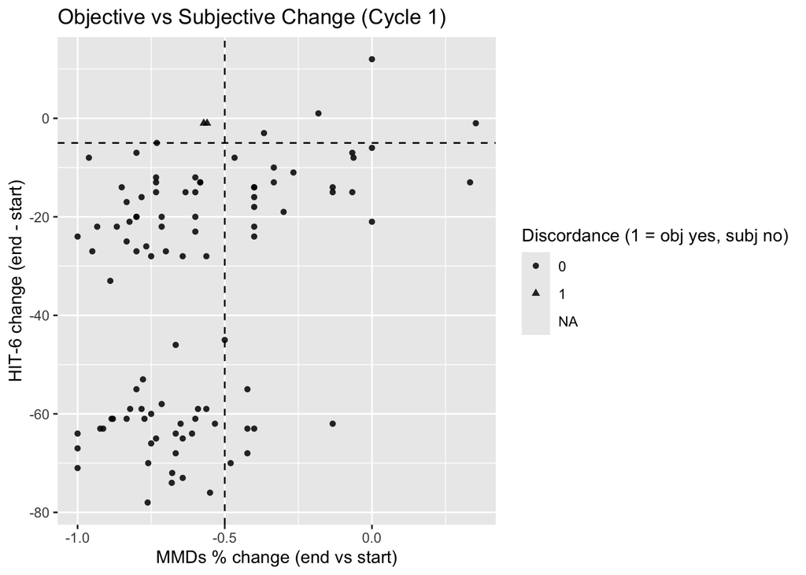

```r
# ------------------------------------------------------------------
# Scatter plot: objective vs subjective change (Δ vs Δ)
# ------------------------------------------------------------------
# X axis: % change in MMDs (end vs start)
# Y axis: change in HIT-6 (end - start)
# Thresholds:
# - Objective responder: pct_change_MMDs <= -0.50
# - Subjective responder: delta_HIT6 <= -5

# Create a quadrant label for interpretation (optional but useful)
c1_change <- c1_change %>%
  mutate(
    quadrant = case_when(
  is.na(obj_resp) | is.na(subj_resp) ~ "Missing responder status",
  obj_resp == 1L & subj_resp == 1L ~ "Concordant responders",
  obj_resp == 1L & subj_resp == 0L ~ "Discordant (obj yes, subj no)",
  obj_resp == 0L & subj_resp == 1L ~ "Discordant (obj no, subj yes)",
  TRUE ~ "Concordant non-responders"
)
)


# Scatter plot
p_scatter <- ggplot(c1_change, aes(x = pct_change_MMDs, y = delta_HIT6)) +
  # Decision thresholds
  geom_vline(xintercept = -0.50, linetype = "dashed") +
  geom_hline(yintercept = -5, linetype = "dashed") +
  # Points (shape indicates discordance)
  geom_point(aes(shape = factor(discordance)), alpha = 0.85) +
  labs(
    title = "Objective vs Subjective Change (Cycle 1)",
    x = "MMDs % change (end vs start)",
    y = "HIT-6 change (end - start)",
    shape = "Discordance (1 = obj yes, subj no)"
  )

p_scatter
```

```r
# Save the figure
ggsave("outputs/task1/figures/scatter_mmds_pct_vs_hit6_delta_main.png", p_scatter, width = 7, height = 5)
```

The scatter plot provides the core representation of objective-subjective agreement.

Patients with x ≤ -0.50 but y> -5 fall into the primary discordant region (objective responder without a clinically meaningful HIT-6 improvement). Conversely, patients with x > -0.50 but y ≤-5 show the opposite discordance pattern (subjective improvement without meeting the objective responder definition). This visual summary complements the 2x2 table, by showing the magnitude and variability of changes within each quadrant.

=============================================================================== To complement the scatter plot, we summarise the distribution of patients across the four response quadrants (- **concordant responders**, concordant non-responders, and the two discordant profiles). This provides an immediate quantitative breakdown of mismatch patterns at the end of Cycle 1.

```r
# ------------------------------------------------------------------
# Example counts per quadrant (quick summary)
# ------------------------------------------------------------------

quad_summary <- c1_change %>%
  count(quadrant, name = "n") %>%
  mutate(pct = 100* n / sum(n)) %>%
  arrange(desc(n))

quad_summary
```

```
## # A tibble: 5 × 3
##   quadrant                          n   pct
##   <chr>                         <int> <dbl>
## 1 Missing responder status         81 45.3
## 2 Concordant responders            67 37.4
## 3 Discordant (obj no, subj yes)    25 14.0
## 4 Concordant non-responders         4  2.23
## 5 Discordant (obj yes, subj no)     2  1.12
```

```r
readr::write_csv(quad_summary, "outputs/task1/quadrant_summary_main.csv")
```

The quadrant summary quantifies how patients are distributed across concordant and discordant profiles, complementing the visual scatter plot with exact counts and percentages.

In particular, the *discordant (obj yes, subj no)* group directly captures the primary mismatch of interest: patients achieving a substantial reduction in migraine frequency without reporting a clinically meaningful improvement in HIT-6. Conversely, the *discordant (obj no, subj yes)* group highlights the opposite pattern, i.e., subjective improvement without meeting the objective responder criterion.

# ===============================================================================

**Sensitivity analysis (LOCF vs interpolation)** To assess the robustness of the objective–subjective mismatch results, we repeat the core analyses of Task 1 using an alternative longitudinal dataset based on Last Observation Carried Forward (LOCF) imputation.

The goal of this sensitivity analysis is not to introduce new models or definitions, but to verify whether the estimated longitudinal trends and the responder/discordance classification are consistent across different missing-data handling strategies.

We first refit the same linear mixed-effects models for MMDs and HIT-6 using the SENS dataset. Model structure, fixed effects and random effects specification are kept identical to the main analysis, ensuring direct comparability of results.

```r
# ------------------------------------------------------------------
# Mixed models on SENS dataset (LOCF)
# ------------------------------------------------------------------

library(lme4)
library(lmerTest)

# SENS dataset (LOCF-based)
dat_sens <- data_task1_sens

# Objective outcome: Monthly Migraine Days
mod_mmds_sens <- lmer(
  MMDs ~ CYCLE + MONTH_num + (1 | SUBJECT_ID),
  data = dat_sens,
  REML = FALSE
)

# Subjective outcome: HIT-6
mod_hit6_sens <- lmer(
  HIT6 ~ CYCLE + MONTH_num + (1 | SUBJECT_ID),
  data = dat_sens,
  REML = FALSE
)

summary(mod_mmds_sens)
```

```
## Linear mixed model fit by maximum likelihood . t-tests use Satterthwaite's
##   method [lmerModLmerTest]
## Formula: MMDs ~ CYCLE + MONTH_num + (1 | SUBJECT_ID)
##    Data: dat_sens
##
##       AIC       BIC    logLik -2*log(L)  df.resid
##   11630.5   11663.3   -5809.2   11618.5      1754
##
## Scaled residuals:
##     Min      1Q  Median      3Q     Max
## -3.7835 -0.6128 -0.0723  0.5315  3.4341
##
## Random effects:
##  Groups     Name        Variance Std.Dev.
##  SUBJECT_ID (Intercept) 48.05    6.932
##  Residual               33.03    5.747
## Number of obs: 1760, groups:  SUBJECT_ID, 179
##
## Fixed effects:
##               Estimate Std. Error         df t value Pr(>|t|)
## (Intercept)   18.67127    0.59271  245.64737  31.502  < 2e-16 ***
## CYCLE2        -0.99660    0.36548 1649.05430  -2.727  0.00646 **
## CYCLE3        -2.00677    0.39427 1651.72976  -5.090 3.99e-07 ***
## MONTH_num     -0.62944    0.03458 1572.91538 -18.205  < 2e-16 ***
## ---
## Signif. codes:  0 '***' 0.001 '**' 0.01 '*' 0.05 '.' 0.1 ' ' 1
##
## Correlation of Fixed Effects:
##           (Intr) CYCLE2 CYCLE3
## CYCLE2    -0.159
## CYCLE3    -0.153  0.450
## MONTH_num -0.362 -0.032 -0.014
```

```r
summary(mod_hit6_sens)
```

```
## Linear mixed model fit by maximum likelihood . t-tests use Satterthwaite's
##   method [lmerModLmerTest]
## Formula: HIT6 ~ CYCLE + MONTH_num + (1 | SUBJECT_ID)
##    Data: dat_sens
##
##       AIC       BIC    logLik -2*log(L)  df.resid
##   13048.2   13080.8   -6518.1   13036.2      1666
##
## Scaled residuals:
##     Min      1Q  Median      3Q     Max
## -4.6671 -0.3271  0.1358  0.5582  2.3452
##
## Random effects:
##  Groups     Name        Variance Std.Dev.
##  SUBJECT_ID (Intercept)  26.03    5.102
##  Residual               127.90   11.309
## Number of obs: 1672, groups:  SUBJECT_ID, 179
##
## Fixed effects:
##               Estimate Std. Error         df t value Pr(>|t|)
## (Intercept)   64.79602    0.73262  656.27151  88.444  < 2e-16 ***
## CYCLE2         2.35869    0.71004 1535.05601   3.322 0.000915 ***
## CYCLE3        -1.04164    0.75810 1669.41219  -1.374 0.169622
## MONTH_num     -1.32404    0.06963 1483.63856 -19.016  < 2e-16 ***
## ---
## Signif. codes:  0 '***' 0.001 '**' 0.01 '*' 0.05 '.' 0.1 ' ' 1
##
## Correlation of Fixed Effects:
##           (Intr) CYCLE2 CYCLE3
## CYCLE2    -0.425
## CYCLE3    -0.341  0.442
## MONTH_num -0.589 -0.003 -0.001
```

```r
# Optional HADS models (only if available)
mods_optional_sens <- list()

if ("HADSA" %in% names(dat_sens)) {
  mods_optional_sens$hadsa_sens <- lmer(HADSA ~ CYCLE + MONTH_num + (1 | SUBJECT_ID),
                                       data = dat_sens, REML = FALSE)
}

if ("HADSD" %in% names(dat_sens)) {
  mods_optional_sens$hadsd_sens <- lmer(HADSD ~ CYCLE + MONTH_num + (1 | SUBJECT_ID),
                                       data = dat_sens, REML = FALSE)
}

if (length(mods_optional_sens) > 0) lapply(mods_optional_sens, summary)
```

```
## $hadsa_sens
## Linear mixed model fit by maximum likelihood . t-tests use Satterthwaite's
##   method [lmerModLmerTest]
## Formula: HADSA ~ CYCLE + MONTH_num + (1 | SUBJECT_ID)
##    Data: dat_sens
##
##       AIC       BIC    logLik -2*log(L)  df.resid
##    5262.6    5291.2   -2625.3    5250.6       864
##
## Scaled residuals:
##     Min      1Q  Median      3Q     Max
## -1.6186 -0.3750 -0.1222  0.2282 15.8048
##
## Random effects:
##  Groups     Name        Variance Std.Dev.
##  SUBJECT_ID (Intercept)  7.661   2.768
##  Residual               21.196   4.604
## Number of obs: 870, groups:  SUBJECT_ID, 85
##
## Fixed effects:
##              Estimate Std. Error        df t value Pr(>|t|)
## (Intercept)   6.42116    0.51932 301.88406  12.364   <2e-16 ***
## CYCLE2       -0.55573    0.41882 869.17742  -1.327   0.1849
## CYCLE3       -0.56522    0.42931 781.67156  -1.317   0.1884
## MONTH_num    -0.11481    0.03932 781.67156  -2.920   0.0036 **
## ---
## Signif. codes:  0 '***' 0.001 '**' 0.01 '*' 0.05 '.' 0.1 ' ' 1
##
## Correlation of Fixed Effects:
##           (Intr) CYCLE2 CYCLE3
## CYCLE2    -0.559
## CYCLE3    -0.413  0.513
## MONTH_num -0.469  0.000  0.000
##
## $hadsd_sens
## Linear mixed model fit by maximum likelihood . t-tests use Satterthwaite's
##   method [lmerModLmerTest]
## Formula: HADSD ~ CYCLE + MONTH_num + (1 | SUBJECT_ID)
##    Data: dat_sens
##
```

[output cut: 12 more lines]

```
##
## Fixed effects:
##              Estimate Std. Error        df t value Pr(>|t|)
## (Intercept)   5.76124    0.49545 147.39087  11.628  < 2e-16 ***
## CYCLE2        0.35002    0.27287 823.79219   1.283 0.199937
## CYCLE3        0.60435    0.26984 783.97846   2.240 0.025395 *
## MONTH_num    -0.09198    0.02471 783.97846  -3.722 0.000212 ***
## ---
## Signif. codes:  0 '***' 0.001 '**' 0.01 '*' 0.05 '.' 0.1 ' ' 1
##
## Correlation of Fixed Effects:
##           (Intr) CYCLE2 CYCLE3
## CYCLE2    -0.391
## CYCLE3    -0.272  0.494
## MONTH_num -0.309  0.000  0.000
```

We export fixed-effects tables (β, SE, 95% CI) for the SENS mixed models using the same tidying procedure adopted in the main analysis. This enables an immediate comparison of the direction and relative magnitude of cycle/month effects across missing-data strategies.

```r
# ------------------------------------------------------------------
# Export fixed effects tables (SENS)
# ------------------------------------------------------------------

if (!requireNamespace("broom.mixed", quietly = TRUE)) install.packages("broom.mixed")
library(broom.mixed)

dir.create("outputs/task1", recursive = TRUE, showWarnings = FALSE)

fx_mmds_sens <- tidy(mod_mmds_sens, effects = "fixed", conf.int = TRUE)
fx_hit6_sens <- tidy(mod_hit6_sens, effects = "fixed", conf.int = TRUE)

readr::write_csv(fx_mmds_sens, "outputs/task1/fixed_effects_mmds_sens.csv")
readr::write_csv(fx_hit6_sens, "outputs/task1/fixed_effects_hit6_sens.csv")

# Optional models (if fitted)
if (exists("mods_optional_sens") && length(mods_optional_sens) > 0) {
  fx_optional_sens <- purrr::imap_dfr(
    mods_optional_sens,
    ~ tidy(.x, effects = "fixed", conf.int = TRUE) %>% dplyr::mutate(model = .y)
  )
  readr::write_csv(fx_optional_sens, "outputs/task1/fixed_effects_optional_sens.csv")
}

fx_mmds_sens
```

```
## # A tibble: 4 × 9
##   effect term     estimate std.error statistic    df  p.value conf.low conf.high
##   <chr>  <chr>       <dbl>     <dbl>     <dbl> <dbl>    <dbl>    <dbl>     <dbl>
## 1 fixed  (Interc…   18.7      0.593      31.5   246. 3.03e-88   17.5      19.8
## 2 fixed  CYCLE2     -0.997    0.365      -2.73 1649. 6.46e- 3   -1.71     -0.280
## 3 fixed  CYCLE3     -2.01     0.394      -5.09 1652. 3.99e- 7   -2.78     -1.23
## 4 fixed  MONTH_n…   -0.629    0.0346    -18.2  1573. 2.37e-67   -0.697    -0.562
```

```r
fx_hit6_sens
```

```
## # A tibble: 4 × 9
##   effect term     estimate std.error statistic    df  p.value conf.low conf.high
##   <chr>  <chr>       <dbl>     <dbl>     <dbl> <dbl>    <dbl>    <dbl>     <dbl>
## 1 fixed  (Interc…    64.8     0.733      88.4   656. 0          63.4      66.2
## 2 fixed  CYCLE2       2.36    0.710       3.32 1535. 9.15e- 4    0.966     3.75
## 3 fixed  CYCLE3      -1.04    0.758      -1.37 1669. 1.70e- 1   -2.53      0.445
## 4 fixed  MONTH_n…    -1.32    0.0696    -19.0  1484. 2.52e-72   -1.46     -1.19
```

=============================================================================== We replicate the “core” descriptive trend plots on the SENS dataset (LOCF), summarising mean ± standard error at each scheduled follow-up month within cycle. These figures provide a transparent visual check that average trajectories are not materially altered by the LOCF strategy.

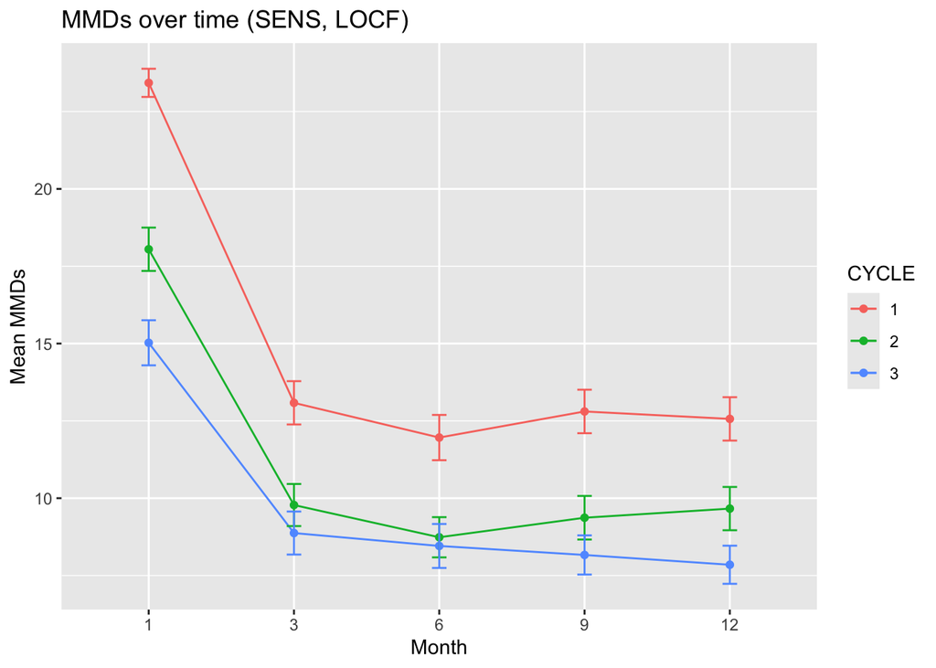

```r
# ------------------------------------------------------------------
# Core plots (SENS): mean ± SE trends by (CYCLE, MONTH)
# ------------------------------------------------------------------

dir.create("outputs/task1/figures", recursive = TRUE, showWarnings = FALSE)

trend_sens <- data_task1_sens %>%
  group_by(CYCLE, MONTH) %>%
  summarise(
    n_MMDs = sum(!is.na(MMDs)),
    mean_MMDs = mean(MMDs, na.rm = TRUE),
    se_MMDs = if_else(n_MMDs > 1, sd(MMDs, na.rm = TRUE) / sqrt(n_MMDs), NA_real_),

    n_HIT6 = sum(!is.na(HIT6)),
    mean_HIT6 = mean(HIT6, na.rm = TRUE),
    se_HIT6 = if_else(n_HIT6 > 1, sd(HIT6, na.rm = TRUE) / sqrt(n_HIT6), NA_real_),
    .groups = "drop"
  )

p_mmds_sens <- ggplot(trend_sens, aes(x = MONTH, y = mean_MMDs, group = CYCLE, color = CYCLE)) +
  geom_line() +
  geom_point() +
  geom_errorbar(aes(ymin = mean_MMDs - se_MMDs, ymax = mean_MMDs + se_MMDs), width = 0.1) +
  labs(title = "MMDs over time (SENS, LOCF)", x = "Month", y = "Mean MMDs")

p_hit6_sens <- ggplot(trend_sens, aes(x = MONTH, y = mean_HIT6, group = CYCLE, color = CYCLE)) +
  geom_line() +
  geom_point() +
  geom_errorbar(aes(ymin = mean_HIT6 - se_HIT6, ymax = mean_HIT6 + se_HIT6), width = 0.1) +
  labs(title = "HIT-6 over time (SENS, LOCF)", x = "Month", y = "Mean HIT-6")

p_mmds_sens
```

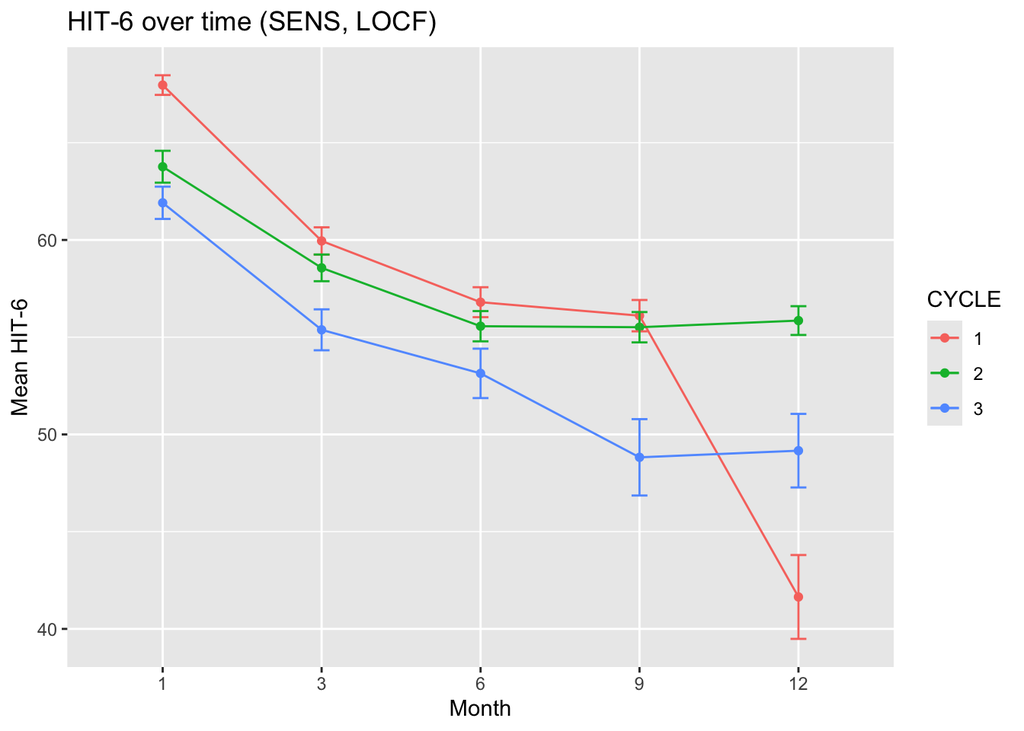

```r
p_hit6_sens
```

```r
ggsave("outputs/task1/figures/trend_mmds_sens.png", p_mmds_sens, width = 7, height = 4)
ggsave("outputs/task1/figures/trend_hit6_sens.png", p_hit6_sens, width = 7, height = 4)

readr::write_csv(trend_sens, "outputs/task1/trend_summary_sens.csv")
```

The resulting figures show that the overall temporal patterns for MMDs and HIT-6 are broadly consistent with the main analysis. Minor differences in the magnitude of means at specific visits are expected under LOCF, but the qualitative trajectories across months/cycles appear comparable. =============================================================================== As an exploratory complement to the mean trends, we visualise individual MMDs trajectories for a random subset of patients in the SENS dataset. This helps verify that LOCF does not mask the strong between-patient heterogeneity already observed in the main analysis.

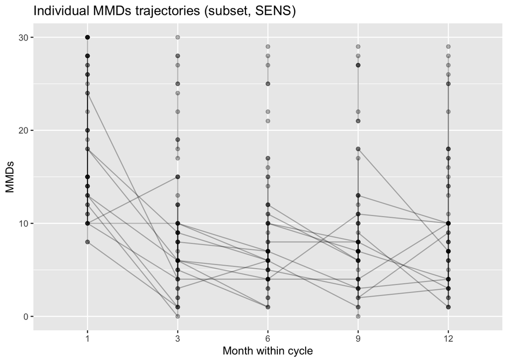

```r
# ------------------------------------------------------------------
# Spaghetti plot (SENS): individual MMDs trajectories
#

set.seed(123)
sample_ids_sens <- sample(unique(data_task1_sens$SUBJECT_ID), 30)

spaghetti_sens <- data_task1_sens %>%
  filter(SUBJECT_ID %in% sample_ids_sens)

p_spaghetti_sens <- ggplot(spaghetti_sens, aes(x = MONTH, y = MMDs, group = SUBJECT_ID)) +
  geom_line(alpha = 0.3) +
  geom_point(alpha = 0.3) +
  labs(title = "Individual MMDs trajectories (subset, SENS)", x = "Month within cycle", y = "MMDs")

p_spaghetti_sens
```

```r
ggsave("outputs/task1/figures/spaghetti_mmds_sens.png", p_spaghetti_sens, width = 7, height = 4)
```

The spaghetti plot confirms substantial inter-individual variability in MMDs trajectories, even under LOCF. Therefore, any conclusions based only on average trends should be interpreted together with the heterogeneity visible at the patient level. =============================================================================== We then replicate the Cycle 1 responder classification on the SENS dataset using the same clinically motivated thresholds adopted in the main analysis.

Objective and subjective responders are defined using identical cut-offs, and discordance is again defined as objective response without subjective improvement.

```r
# ------------------------------------------------------------------
# Cycle 1 responder and discordance definition (SENS)
# ------------------------------------------------------------------

# Select Cycle 1
c1_sens <- data_task1_sens %>%
  filter(CYCLE == "1") %>%
  mutate(month_num = as.numeric(as.character(MONTH))) %>%
  arrange(SUBJECT_ID, month_num)

# Start of cycle (Month 1)
c1_start_sens <- c1_sens %>%
  filter(month_num == 1) %>%
  select(
    SUBJECT_ID,
    MMDs_start = MMDs,
    HIT6_start = HIT6
  )

# End of cycle (Month 12 or last observed)
c1_end_sens <- c1_sens %>%
  group_by(SUBJECT_ID) %>%
  filter(month_num == max(month_num, na.rm = TRUE)) %>%
  slice_tail(n = 1) %>%
  ungroup() %>%
  select(
    SUBJECT_ID,
    end_month = month_num,
    MMDs_end = MMDs,
    HIT6_end = HIT6
  )

cat("End month distribution (SENS):\n")
```

```
## End month distribution (SENS):
```

```r
print(table(c1_end_sens$end_month, useNA = "ifany"))
```

```
##
##  12
## 179
```

```r
# Merge and compute changes
c1_change_sens <- c1_start_sens %>%
  inner_join(c1_end_sens, by = "SUBJECT_ID") %>%
  mutate(
    pct_change_MMDs = if_else(
      !is.na(MMDs_start) & MMDs_start > 0,
      (MMDs_end - MMDs_start) / MMDs_start,
      NA_real_
    ),
    delta_HIT6 = HIT6_end - HIT6_start
  )

# Define responders
c1_change_sens <- c1_change_sens %>%
  mutate(
    obj_resp = case_when(
      is.na(pct_change_MMDs) ~ NA_integer_,
      pct_change_MMDs <= -0.50 ~ 1L,
      TRUE ~ 0L
    ),
    subj_resp = case_when(
      is.na(delta_HIT6) ~ NA_integer_,
      delta_HIT6 <= -5 ~ 1L,
      TRUE ~ 0L
    ),
    discordance = case_when(
      is.na(obj_resp) | is.na(subj_resp) ~ NA_integer_,
      obj_resp == 1L & subj_resp == 0L ~ 1L,
      TRUE ~ 0L
    )
  )


cat("Objective responder rate (SENS):", mean(c1_change_sens$obj_resp, na.rm = TRUE), "\n")
```

```
## Objective responder rate (SENS): 0.547486
```

```r
cat("Subjective responder rate (SENS):", mean(c1_change_sens$subj_resp, na.rm = TRUE), "\n")
```

```
## Subjective responder rate (SENS): 0.7785714
```

```r
cat("Discordance rate (SENS):", mean(c1_change_sens$discordance, na.rm = TRUE), "\n")
```

```
## Discordance rate (SENS): 0.05
```

```r
# Save dataset
readr::write_csv(
  c1_change_sens,
  "outputs/task1/cycle1_responder_discordance_sens.csv"
)
```

=============================================================================== We reproduce the mismatch outputs on the SENS dataset: 1) a 2×2 table of objective vs subjective response with percentages;  
2) a scatter plot of objective vs subjective change with clinical thresholds defining quadrants;  
3) a quadrant summary reporting counts and percentages per profile.

```r
# ------------------------------------------------------------------
# 2x2 responder table (SENS)
# ------------------------------------------------------------------

tab_2x2_sens <- c1_change_sens %>%
  filter(!is.na(obj_resp), !is.na(subj_resp)) %>%
  count(obj_resp, subj_resp, name = "n") %>%
  mutate(pct_total = 100 * n / sum(n))


tab_2x2_sens
```

```
## # A tibble: 4 × 4
##   obj_resp subj_resp     n pct_total
##      <int>     <int> <int>     <dbl>
## 1        0         0    24      17.1
## 2        0         1    34      24.3
## 3        1         0     7       5
## 4        1         1    75      53.6
```

```r
readr::write_csv(tab_2x2_sens, "outputs/task1/responder_2x2_sens.csv")
```

We now reproduce the key mismatch visualisation on the SENS dataset. Each point represents one patient, with the x-axis showing the percentage change in MMDs from Month 1 to the end of Cycle 1 and the y-axis showing the corresponding change in HIT-6. The dashed lines indicate the same clinical thresholds used in the main analysis (≥50% MMDs reduction, ≥ 5 point HIT-6 improvement), defining the four response quadrants.

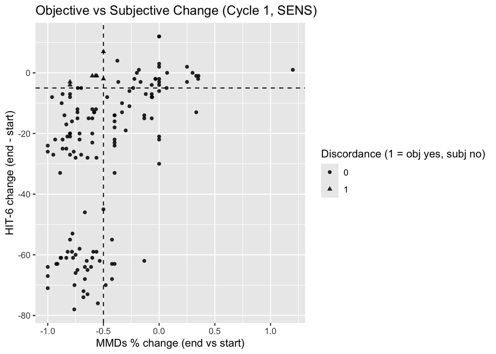

```r
# ------------------------------------------------------------------
# Scatter plot: pct_change_MMDs vs delta_HIT6 (SENS)
# ------------------------------------------------------------------

c1_change_sens <- c1_change_sens %>%
  mutate(
    quadrant = case_when(
  is.na(obj_resp) | is.na(subj_resp) ~ "Missing responder status",
  obj_resp == 1L & subj_resp == 1L ~ "Concordant responders",
  obj_resp == 1L & subj_resp == 0L ~ "Discordant (obj yes, subj no)",
  obj_resp == 0L & subj_resp == 1L ~ "Discordant (obj no, subj yes)",
  TRUE ~ "Concordant non-responders"
)
,
    #primary discordance of interest: objective yes, subjective no
    discordant_primary = if_else(
  !is.na(obj_resp) & !is.na(subj_resp) & obj_resp == 1L & subj_resp == 0L,
  1L, 0L
)
)

p_scatter_sens <- ggplot(c1_change_sens, aes(x = pct_change_MMDs, y = delta_HIT6)) +
  geom_vline(xintercept = -0.50, linetype = "dashed") +
  geom_hline(yintercept = -5, linetype = "dashed") +
  geom_point(aes(shape = factor(discordant_primary)), alpha = 0.85) +
  labs(
    title = "Objective vs Subjective Change (Cycle 1, SENS)",
    x = "MMDs % change (end vs start)",
    y = "HIT-6 change (end - start)",
    shape = "Discordance (1 = obj yes, subj no)"
  )

p_scatter_sens
```

```r
ggsave("outputs/task1/figures/scatter_mmds_pct_vs_hit6_delta_sens.png", p_scatter_sens, width = 7, height = 5)

# ---- Micro-check  (SENS) ----
table(c1_change_sens$obj_resp, useNA = "ifany")
```

```
##
##  0  1
## 81 98
```

```r
table(c1_change_sens$subj_resp, useNA = "ifany")
```

```
##
##    0    1 <NA>
##   31  109   39
```

```r
table(c1_change_sens$discordance, useNA = "ifany")
```

```
##
##    0    1 <NA>
##  133    7   39
```

The scatter plot provides a direct confirmation that an objective-subjective mismatch persists under LOCF. In particular, patients in the “objective responder / subjective non-responder” quadrant represent the primary discordant profile of interest, supporting that the mismatch is not an artefact of the interpolation strategy.

To complement the scatter plot, we summarise the number and percentage of patients falling into each response quadrant under the SENS strategy. This provides an exact breakdown of concordant vs discordant profiles and facilitates direct comparison with the main analysis.

```r
# ------------------------------------------------------------------
# Quadrant summary (SENS)
# ------------------------------------------------------------------

quad_summary_sens <- c1_change_sens %>%
  count(quadrant, name = "n") %>%
  mutate(pct = 100 * n / sum(n)) %>%
  arrange(desc(n))

quad_summary_sens
```

```
## # A tibble: 5 × 3
##   quadrant                          n   pct
##   <chr>                         <int> <dbl>
## 1 Concordant responders            75 41.9
## 2 Missing responder status         39 21.8
## 3 Discordant (obj no, subj yes)    34 19.0
## 4 Concordant non-responders        24 13.4
## 5 Discordant (obj yes, subj no)     7  3.91
```

```r
readr::write_csv(quad_summary_sens, "outputs/task1/quadrant_summary_sens.csv")
```

Finally, we directly compare the main and sensitivity analyses by: - reporting discordance prevalence under each strategy;  
- comparing the direction of key fixed effects (cycle/month) across datasets. This provides a compact robustness check of the study’s main claim: objective–subjective mismatch is not an artefact of the imputation strategy.

```r
# ------------------------------------------------------------------
# Compare MAIN vs SENS (discordance + fixed effects direction)
# ------------------------------------------------------------------

# Discordance prevalence
disc_compare <- tibble::tibble(
  dataset = c("MAIN (interpolation)", "SENS (LOCF)"),
  n = c(nrow(c1_change), nrow(c1_change_sens)),
  discordance_rate = c(mean(c1_change$discordance, na.rm=TRUE),
                     mean(c1_change_sens$discordance, na.rm=TRUE)),
obj_resp_rate = c(mean(c1_change$obj_resp, na.rm=TRUE),
                  mean(c1_change_sens$obj_resp, na.rm=TRUE)),
subj_resp_rate = c(mean(c1_change$subj_resp, na.rm=TRUE),
                   mean(c1_change_sens$subj_resp, na.rm=TRUE))
)

disc_compare
```

```
## # A tibble: 2 × 5
##   dataset                  n discordance_rate obj_resp_rate subj_resp_rate
##   <chr>                <int>            <dbl>         <dbl>          <dbl>
## 1 MAIN (interpolation)   179           0.0204         0.636          0.939
## 2 SENS (LOCF)            179           0.05           0.547          0.779
```

```r
readr::write_csv(disc_compare, "outputs/task1/compare_main_vs_sens_discordance_rates.csv")

# Fixed effects: compare sign/order on the same terms
fx_mmds_main <- broom.mixed::tidy(mod_mmds, effects = "fixed")
fx_mmds_sens <- broom.mixed::tidy(mod_mmds_sens, effects = "fixed")

fx_hit6_main <- broom.mixed::tidy(mod_hit6, effects = "fixed")
fx_hit6_sens <- broom.mixed::tidy(mod_hit6_sens, effects = "fixed")

compare_fx <- dplyr::bind_rows(
  fx_mmds_main %>% transmute(model = "MMDs", dataset = "MAIN", term, estimate),
  fx_mmds_sens %>% transmute(model = "MMDs", dataset = "SENS", term, estimate),
  fx_hit6_main %>% transmute(model = "HIT6", dataset = "MAIN", term, estimate),
  fx_hit6_sens %>% transmute(model = "HIT6", dataset = "SENS", term, estimate)
) %>%
  tidyr::pivot_wider(names_from = dataset, values_from = estimate) %>%
  mutate(
    sign_MAIN = sign(MAIN),
    sign_SENS = sign(SENS),
    sign_match = (sign_MAIN == sign_SENS)
  ) %>%
  arrange(model, term)

key_terms <- c("CYCLE2", "CYCLE3", "MONTH_num")

compare_fx_key <- compare_fx %>%
  filter(term %in% key_terms) %>%
  arrange(model, match(term, key_terms))

compare_fx_key
```

```
## # A tibble: 6 × 7
##   model term        MAIN   SENS sign_MAIN sign_SENS sign_match
##   <chr> <chr>      <dbl>  <dbl>     <dbl>     <dbl> <lgl>
## 1 HIT6  CYCLE2     3.02   2.36          1         1 TRUE
## 2 HIT6  CYCLE3    -0.631 -1.04         -1        -1 TRUE
## 3 HIT6  MONTH_num -1.52  -1.32         -1        -1 TRUE
## 4 MMDs  CYCLE2    -1.28  -0.997        -1        -1 TRUE
## 5 MMDs  CYCLE3    -2.27  -2.01         -1        -1 TRUE
## 6 MMDs  MONTH_num -0.708 -0.629        -1        -1 TRUE
```

```r
readr::write_csv(compare_fx, "outputs/task1/compare_main_vs_sens_fixed_effects_sign.csv")
readr::write_csv(compare_fx_key, "outputs/task1/compare_main_vs_sens_fixed_effects_sign_keyterms.csv")
```

Fixed-effect directions for the main drivers (cycle contrasts and the numeric follow-up time effect, MONTH_num) were consistent between MAIN and SENS, indicating that the qualitative association of follow-up time and treatment cycle with both outcomes is not sensitive for the imputation strategy.

Overall, this sensitivity analysis supports the robustness of the main Task 1 findings.

=================================================================== **Interpretation of Task 1**

On average, both objective (MMDs) and subjective (HIT-6) outcomes improve over time under anti-CGRP treatment, as shown by the mixed-effects models and longitudinal trend plots.

These results motivate further investigation into patient-level factors potentially associated with discordance, such as psychological comorbidities (HADS), sleep-related variables, and other baseline characteristics (Task 2).